# Lexical of 20th century Odyssey translations (Part B): Etymologies

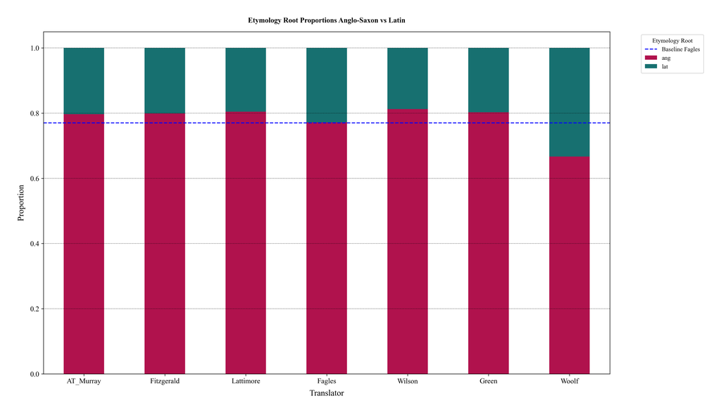

```
time: 770 ms (started: 2025-04-22 02:29:58 +02:00)
```

```python
# ----------------------------------------------------------------------
# Comparing etymological distributions as proportions
# ----------------------------------------------------------------------

# Step 1. Normilize the etymology counts by token-row length
def normalize_etymologies(row):
    total_tokens = len(row['tokens'])
    return {k: v / total_tokens for k, v in row['etymology_counts'].items()}

odysseys_df['normalized_etymology'] = odysseys_df.apply(normalize_etymologies, axis=1)

# Step 2. Aggregate the normalized etymologies by translator
translator_agg = defaultdict(lambda: defaultdict(float))

for _, row in odysseys_df.iterrows():
    translator = row['translator']
    for k, v in row['normalized_etymology'].items():
        translator_agg[translator][k] += v

agg_df = pd.DataFrame(translator_agg).fillna(0).T  # shape: (n_translators, n_roots)

# Step 3. Filter fand normalize
top_roots = [  'ang', 'lat']
filtered_df = agg_df[top_roots]
prop_df = filtered_df.div(filtered_df.sum(axis=1), axis=0)

# Step 4. Plot the results
prop_df.plot(kind='bar', stacked=True, color=['#B0124D', '#177070'])
plt.title("Etymology Root Proportions Anglo-Saxon vs Latin")
plt.xlabel("Translator", fontsize=14)
plt.xticks(rotation=0, fontsize=12)
plt.yticks(fontsize=12)
plt.ylabel("Proportion", fontsize=14)
plt.axhline(0.77, color='blue', linestyle='--', label='Baseline Fagles')
plt.grid(axis='y', linestyle='--', linewidth=0.5, alpha=0.7)
plt.legend(title="Etymology Root", bbox_to_anchor=(1.05, 1), loc='upper left')
plt.tight_layout()
plt.savefig(f"{output_path_plots}Etymology_Root_Proportions_AngLat-{nb_id}.png")
plt.show()
```

```
            cosine_dist_from_mean
AT_Murray  0.0024429419
Fitzgerald 0.0000973649
Lattimore  0.0003457566
Fagles     0.0000901285
Wilson     0.0009285934
Green      0.0004112601
Woolf      0.0061264767
```

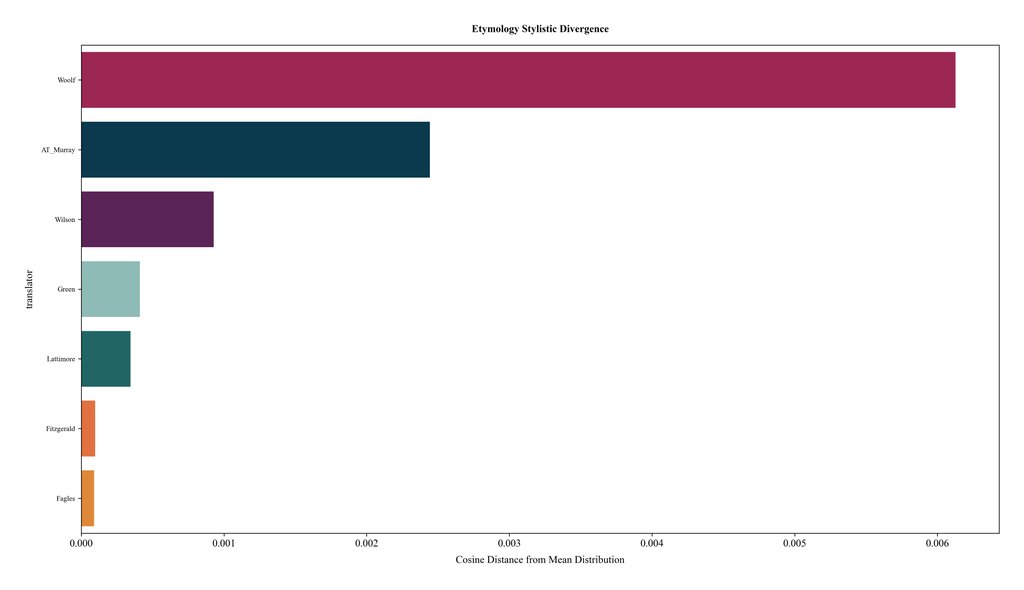

```
time: 720 ms (started: 2025-04-22 02:29:58 +02:00)
```

```python
#-------------------------------------------------------------------
# Etymology distributions to show stylistic divergence
#-------------------------------------------------------------------

# Step 1. Normilize the etymology counts by token-row length
def normalize_etymologies(row):
    total_tokens = len(row['tokens'])
    return {k: v / total_tokens for k, v in row['etymology_counts'].items()}

odysseys_df['normalized_etymology'] = odysseys_df.apply(normalize_etymologies, axis=1)

# Step 2. Aggregate the normalized etymologies by translator
translator_agg = defaultdict(lambda: defaultdict(float))

for _, row in odysseys_df.iterrows():
    translator = row['translator']
    for k, v in row['normalized_etymology'].items():
        translator_agg[translator][k] += v

agg_df = pd.DataFrame(translator_agg).fillna(0).T  # shape: (n_translators, n_roots)

# Step 3. Filter for the top 7 roots
top_roots = ['eng', 'enm', 'ang', 'lat', 'fro', 'non', 'grc']
filtered_df = agg_df[top_roots]

# Step 4. Normalize so rows sum to 1 (per translator)
prop_df = filtered_df.div(filtered_df.sum(axis=1), axis=0)

# Step 5. Compare each translator to the mean distribution
mean_dist = prop_df.mean().values  # .values = 1D numpy array
prop_df['cosine_dist_from_mean'] = prop_df.apply(lambda row: cosine(row.values, mean_dist), axis=1)

#-------------------------------------------------------------------
# Output and viz
#-------------------------------------------------------------------

# Print with full precision to catch small differences
with pd.option_context('display.float_format', '{:.10f}'.format):
    print(prop_df[['cosine_dist_from_mean']])

# Sort and rename for plotting
prop_df_sorted = prop_df.sort_values("cosine_dist_from_mean", ascending=False).reset_index()
prop_df_sorted.rename(columns={"index": "translator"}, inplace=True)

sns.barplot(
    data=prop_df_sorted.reset_index(),
    x="cosine_dist_from_mean", y="translator",
    palette=palette,
    hue="translator", dodge=False,
)
plt.xlabel("Cosine Distance from Mean Distribution")
plt.title("Etymology Stylistic Divergence")
plt.tight_layout()
plt.savefig(f"{output_path_plots}Etymo_Stylistic_Divergence-{nb_id}.png", dpi=300, bbox_inches='tight')
plt.show()
```

```
            cosine_dist_from_mean
AT_Murray  0.0003544942
Fitzgerald 0.0004376970
Lattimore  0.0007190432
Fagles     0.0000609730
Wilson     0.0012118305
Green      0.0006088202
Woolf      0.0174467372
```

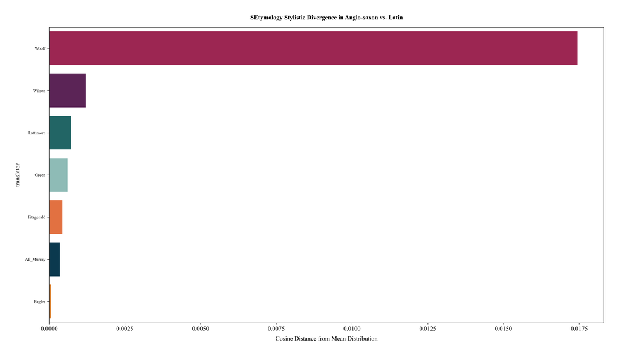

```
time: 718 ms (started: 2025-04-22 02:29:59 +02:00)
```

```python
#-------------------------------------------------------------------
# Etymology poles: anglo-saxon vs. latin
#-------------------------------------------------------------------

top_roots = ['ang', 'lat']
filtered_df = agg_df[top_roots]

# Normalize so rows sum to 1 (per translator)
prop_df = filtered_df.div(filtered_df.sum(axis=1), axis=0)

# Compare each translator to the mean distribution
mean_dist = prop_df.mean().values  # .values = 1D numpy array
prop_df['cosine_dist_from_mean'] = prop_df.apply(lambda row: cosine(row.values, mean_dist), axis=1)

# Print with full precision to catch small differences
with pd.option_context('display.float_format', '{:.10f}'.format):
    print(prop_df[['cosine_dist_from_mean']])


prop_df_sorted = prop_df.sort_values("cosine_dist_from_mean", ascending=False).reset_index()
prop_df_sorted.rename(columns={"index": "translator"}, inplace=True)

sns.barplot(
    data=prop_df_sorted.reset_index(),
    x="cosine_dist_from_mean", y="translator",
    palette=palette,
    hue="translator", dodge=False,
)
plt.xlabel("Cosine Distance from Mean Distribution")
plt.title("SEtymology Stylistic Divergence in Anglo-saxon vs. Latin")
plt.tight_layout()
plt.savefig(f"{output_path_plots}Etymo_Divergence_Ang_Lat-{nb_id}.png", dpi=300, bbox_inches='tight')
plt.show()
```

```python
#-------------------------------------------------------------------
# Etymology-Weighted TF-IDF
#-------------------------------------------------------------------

# Explode tokens column
translator_docs = odysseys_df.groupby("translator", sort=False)["tokens"]\
                             .apply(lambda x: " ".join([token for sublist in x for token in sublist]))

# Compute TF-IDF
tfidf = TfidfVectorizer(lowercase=False, tokenizer=lambda x: x.split())
tfidf_matrix = tfidf.fit_transform(translator_docs)
tfidf_df = pd.DataFrame(tfidf_matrix.toarray(), index=translator_docs.index, columns=tfidf.get_feature_names_out())

etym_dict = {word: get_etymology("eng: " + word, relation_etymology_df)[-1] for word in tfidf_df.columns}

# Initialize etymology-weighted TF-IDF
etym_tfidf = pd.DataFrame(index=tfidf_df.index)

# Map each column (word) to its etym root
for root in set(etym_dict.values()):
    words_with_root = [w for w in tfidf_df.columns if etym_dict.get(w) == root]
    if words_with_root:
        etym_tfidf[root] = tfidf_df[words_with_root].sum(axis=1)

# Normalize the etymology-weighted TF-IDF
etym_tfidf_normalized = etym_tfidf.div(etym_tfidf.sum(axis=1), axis=0)
```

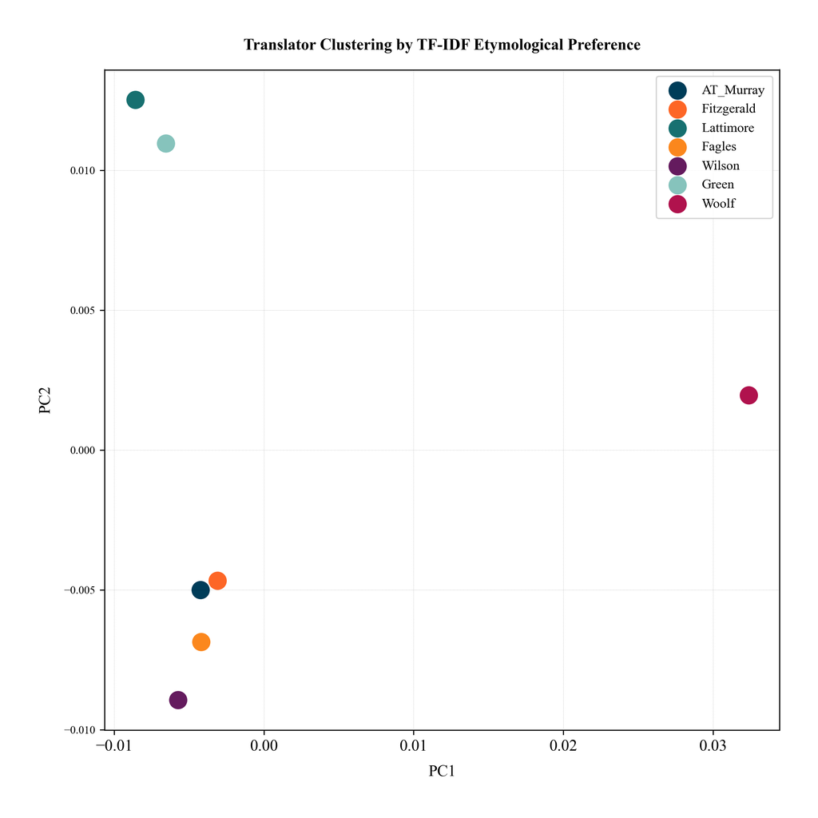

```
time: 788 ms (started: 2025-04-22 02:41:19 +02:00)
```

```python
#-------------------------------------------------------------------
# TF-IDF PCA with Scatterplot
#-------------------------------------------------------------------

pca = PCA(n_components=2)
coords = pca.fit_transform(etym_tfidf_normalized)

plt.figure(figsize=(8,8))
for i, translator in enumerate(etym_tfidf.index):
    plt.scatter(coords[i,0], coords[i,1], label=translator, s=160)
    #plt.text(coords[i,0]+0.01, coords[i,1]+0.01, translator)

plt.title("Translator Clustering by TF-IDF Etymological Preference")
plt.xlabel("PC1")
plt.ylabel("PC2")
plt.legend()
plt.grid(True)
plt.tight_layout()
plt.savefig(f"{output_path_plots}TF-IDF_PCA-{nb_id}.png", dpi=300, bbox_inches='tight')
plt.show()
```

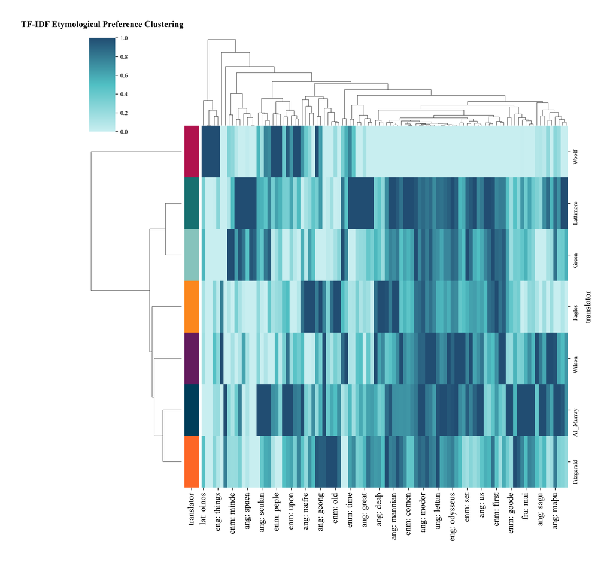

```
time: 1.23 s (started: 2025-04-22 02:41:20 +02:00)
```

```python
#-------------------------------------------------------------------
# TF-IDF Clustering with cluster map
#-------------------------------------------------------------------

top_n = 100
mean_tfidf = etym_tfidf_normalized.mean(axis=0)
top_features = mean_tfidf.sort_values(ascending=False).head(top_n).index

reduced_tfidf = etym_tfidf_normalized[top_features]
scaled = pd.DataFrame(
    StandardScaler().fit_transform(reduced_tfidf),
    index=reduced_tfidf.index,
    columns=reduced_tfidf.columns
)

# Custom palette
top_value = '#214D72'
middle_value = '#50BFC3'
bottom_value = '#C8EEF0'

# Create custom colormap
custom_cmap = LinearSegmentedColormap.from_list('neptune_blue', [bottom_value,  middle_value, top_value])
row_colors = reduced_tfidf.index.to_series().map(palette)
sns.clustermap(
    reduced_tfidf,
    metric="cosine",
    cmap=custom_cmap,
    standard_scale=1,
    row_colors=row_colors
)
plt.title("TF-IDF Etymological Preference Clustering")
plt.savefig(f"{output_path_plots}TF-IDF_Clustermap-{nb_id}.png", dpi=300, bbox_inches='tight')
plt.show()
```

## **Etymology Bias Analysis in Odyssey Translations**

### Overall Etymology Distribution

- Etymology bias across translations is very similar among these Odysseys and difficult to distinguish statistically
- Possible limitation of Menlo's dictionary as our etymology database
- Zooming in on specific root preferences amplifies discrepancies, even when minimal

#### Anglo-Saxon vs Latin Preferences

- **Woolf**: Shows clear preference for Latin forms compared to all translations
- **Some suppossitions**: Hiding away from Latin
  - May reflect translator's agenda
  - Could be attempt to carry source language elements into target language while avoiding Latinate forms
  - Possibly a strategy to distance the Odyssey from Latin successors like Virgil's Aeneid
- **Fagles**: Notably, shows the most Latin usage among the six translators, yet it is prased as "he has found rhythms that correspond well to Homer's rapidity" ([Jenkins, NYT, 1996](https://archive.nytimes.com/www.nytimes.com/books/98/05/31/reviews/fagles-odyssey.html?_r=1&oref=login))

**Nota Bene**: Greek as metric is proportionally tiny. However, further investigation would be interesting.

### Normalized Comparison Against the Mean

#### Overall Etymology

- **Woolf**: Farthest from the mean (as expected)
- **Murray**: Most distinct among the translators
- **Wilson**: Second most distinctive
- **Green & Lattimore**: Form a distinct group
- **Fitzgerald & Fagles**: Closest to the mean

### TF-IDF Weighted Analysis

The tf-idf weighting of etymological bias effectively clusters the translations:

#### Cluster Analysis Results

- **Outlier Group 1**: Lattimore and Green (diverge from main translator group)
- **Outlier Group 2**: Woolf (as expected)
- **Main Cluster**: Fitzgerald, Fagles, Wilson, and Murray

The cluster analysis revealed through both visualization methods (clustermap and scatter plot) that these groupings, show distinct directional differences between the outlier groups.